# CS166 Assignment 3

### Armin Hamp

**18 November, 2019**

```python
#necessary libraries
from matplotlib import pyplot as plt
import matplotlib.cm as cm
import networkx as nx
import numpy as np
import scipy.stats as sts
import random
import itertools
import scipy
```

```python
#loading scripts (see full script in appendix)
%load original_model.py
```

```python
#loading scripts (see full script in appendix)
%load modified_model.py
```

```python
#loading scripts (see full script in appendix)
%load modified_model.py
```

# Modifications

Below is a modified version of the Social Dynamics simulation from Session 7.2. Modifications are explained under the headings below.

## Model Choice

As our simulation is going to run over thousands of iterations, the original graph structure matters very little. Since it is a model that is supposed to simulate social behaviour I implemented rules which bring about preferential attachment between nodes (a very characteristic feature of real social networks).

This means that instead of relying on an original graph structure such as the Barabasi-Albert graph to make my model realistic, I encoded behaviour that uses the theory behind the Barabasi-Albert graph in our update rules. This ensures long term realistic behaviour.

## Multiple topics

Upon interaction between two nodes, an integer between 0 and 9 will determine the index of opinion that should be influenced during the interaction. The formula of the update for opinions remains the same, however at every update only a single opinion will be updated, based on the randomly generated index. This is a realistic assumption of real life exchange of ideas as it is likely two people will discuss a single topic and not all upon interaction.

## Persuasiveness

It is a realistic assumption that instead of a constant $\alpha$ that determines the rate at which nodes adjust their opinions we have a different $\alpha$ for each node, which shall represent how impressionable a person in our simulation is.

To choose an appropriate value for alpha, I modelled this variable using a power-law distribution. As the power law distribution is a common attribute of degree spread in social networks, it is a reasonable assumption for this new variable. The update rules for opinions should stay the same, except now for each node their own $\alpha$ should be considered.

Since the original parameter $\alpha$ of our model was $0.03$, I chose the below parameters for my exponential sampling function to give an appropriate power law distribution for our model.

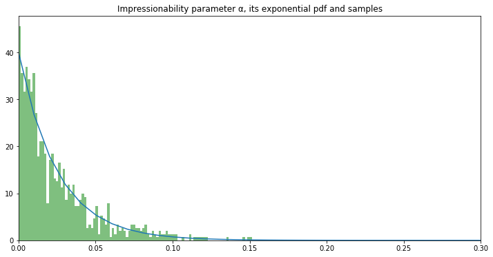

```python
# modeling alpha
x=np.linspace(0,1,100)
y=sts.expon.pdf(x,loc=0,scale=1/40)
y2=sts.expon.rvs(loc=0,scale=1/40,size=1000)
plt.figure(figsize=(12,6))
plt.xlim(0,0.3)
plt.plot(x,y)
plt.hist(y2,normed=True,alpha=0.5,bins=100, color="green")
plt.title("Impressionability parameter α, its exponential pdf and samples")
plt.show()
```

## New Relationships

I changed the rules for the formation of new relationships to more realistically represent social behaviour. As social networks are known to sustain a certain density, new relationships are formed such that it presevres a given density level.

The two nodes that will form a new relationship are selected as follows:

1. Node 1 is chosen as a maximum of a probability table that is constructed by multpiplying a uniformly distributed scalar with node degrees. This means that higher degree nodes will be more likely to form new connections.
2. Node 2 is chosen with a uniform probability.

The weight of each node is a normal distribution around 0.5. Below is a snippet of code for my implementation of new relationships.

```python
#update function, new relationships
if  np.random.normal(nx.density(self.graph),0.01) < 0.1 and random.uniform(0,1)<0.05:
    #ensures new edges added preserve density
    while True:
        nodes = list(self.graph.nodes) #find nodes
        degrees=[self.graph.degree[n] for n in nodes] # find node degrees
        degrees_weighted=[random.uniform(0,1)*i for i in degrees] #a random probability table weighted by degree
        new_edge=(degrees_weighted.index(max(degrees_weighted)),
                  random.choice(nodes)) #new edge formed betweeen highest entry of probability table
        if new_edge not in self.graph.edges and new_edge[0]!=new_edge[1]:
            break #check if edge already exist
    weight=np.random.normal(0.5,0.1)%1 #weight normally distributed around 0.5
    self.graph.add_edge(new_edge[0], new_edge[1], weight=weight) #new edge added
```

# Local Analysis

To analyse the behaviour of our model, I will derive analytically what we should expect in terms of the change of opinion and weight. I will compare these analytical results to vector field plots to verify my results.

## Opinion

The change of opinion of node $i$, $\Delta o$, given two nodes $i$ and $j$, follows the formula $\Delta o_i=\alpha w\times(o_j-o_i)$, where $w$ is the weight of the edge between the two nodes and $\alpha$ is the impressionability constant.

```python
#update rules
#opinion change
def opinion_change(node1,node2,alpha, weight):
    return (alpha * weight * (node2-node1))
#weight change
def weight_change(op_diff,weight,beta,gamma):
    new_weight= beta * weight * (1-weight) *(1 - gamma * op_diff)
    return new_weight
```

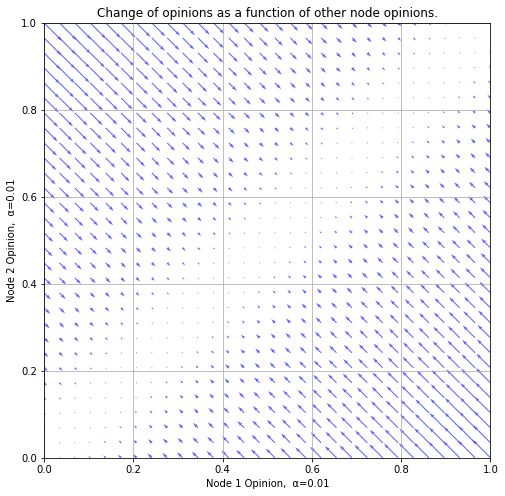

```python
#vector field for opinion change
x, y = np.meshgrid(np.linspace(0,1,30),np.linspace(0,1,30))

shape=x.shape
alpha=0.01
weight=0.5

u = np.zeros(shape)
v = np.zeros(shape)

for i in range(shape[0]):
    for j in range(shape[1]):
        u[i,j]=opinion_change(x[i,j],y[i,j],alpha,weight)
        v[i,j]=opinion_change(y[i,j],x[i,j],alpha,weight)


plt.figure(figsize=(8,8))
plt.quiver(x,y,u,v,scale=1/8, color='blue', alpha=0.6)
plt.grid()
plt.xlim(0,1)
plt.ylim(0,1)
plt.title("Change of opinions as a function of other node opinions.")
plt.xlabel("Node 1 Opinion,  α=0.01")
plt.ylabel("Node 2 Opinion,  α=0.01")
plt.show()
```

As in our model we coded for some variation in the parameter $\alpha$ we can see that while the plot sightly changes it retains its main property of an attractor strip along $x=y$, where $\Delta o \approx 0$.

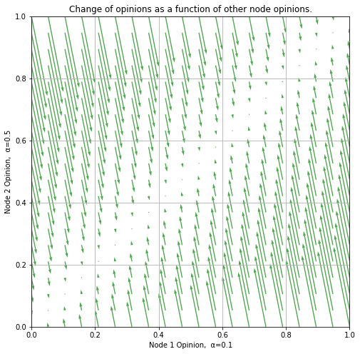

```python
#vector field for opinion change
x, y = np.meshgrid(np.linspace(0,1,20),np.linspace(0,1,20))

shape=x.shape
alpha1=0.1
alpha2=0.5
weight=0.5

u = np.zeros(shape)
v = np.zeros(shape)

for i in range(shape[0]):
    for j in range(shape[1]):
        u[i,j]=opinion_change(x[i,j],y[i,j],alpha1,weight)
        v[i,j]=opinion_change(y[i,j],x[i,j],alpha2,weight)

plt.figure(figsize=(8,8))
plt.quiver(x,y,u,v,scale=1, color='green', alpha=0.7)
plt.grid()
plt.xlim(0,1)
plt.ylim(0,1)
plt.title("Change of opinions as a function of other node opinions.")
plt.xlabel("Node 1 Opinion,  α=0.1")
plt.ylabel("Node 2 Opinion,  α=0.5")
plt.show()
```

## Weights

The weight of the edge between nodes $i$ and $j$ is given by $\Delta w_{ij}=\beta w_{ij}(1-w_{ij})(1-\gamma |o_i-o_j|)$, where $\beta$ is a parameter affecting the rate of weight change and $\gamma$ is the paramater scaling the importance of opinion difference during weight change.

We can see from the equation above that the disagreement term $|o_i-o_j|$ will have the largest effect on $\Delta w{ij}$. To illustrate this, I will plot a vector field of disagreement vs weight.

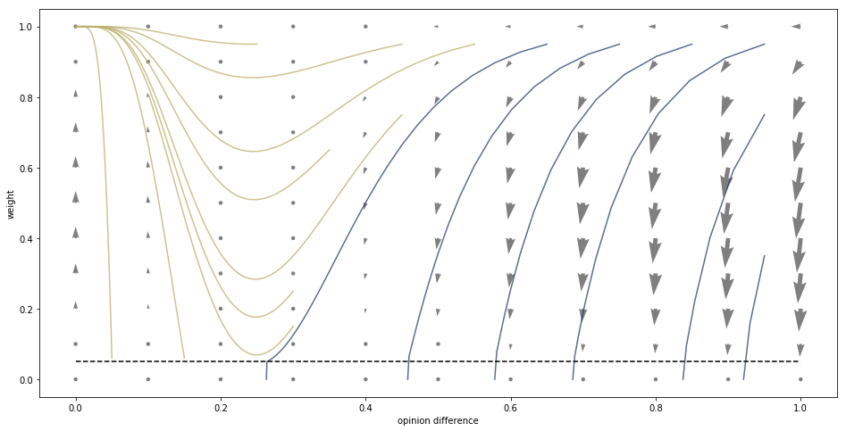

```python
#basic parameters for our model
alpha = 0.03
beta = 0.3
gamma = 4
w_o_plot() #see appendix for code
```

It is true that at certain regions, such as between $0.3<opinion-difference <0.5$, the weight between the two nodes determines which attractor is the edge shall fall into. However, this plot confirms that opinion difference is the greatest factor in determining the long-term behaviour of edges.

## Parameters for our model

The above vector field graphs allow us to pick appropriate parameters for our extended model.